# 2016 Presidential Election Contributions in Ohio by Jamie Brand

### Contributions by gender.

Do genders contribute differently?

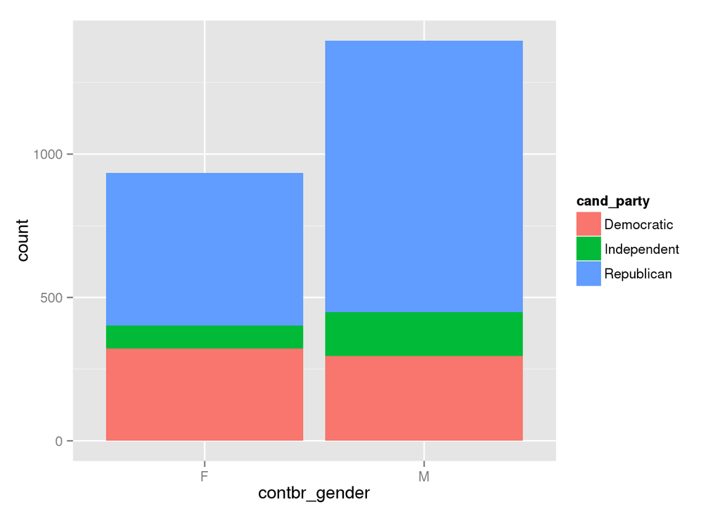

It definitely seems like women are voting more (proportianatly) for democratic candidates and less for republican candidates than men. There may be another factor at work here though. First let’s look at the same data as percentages to make it easier to compare.

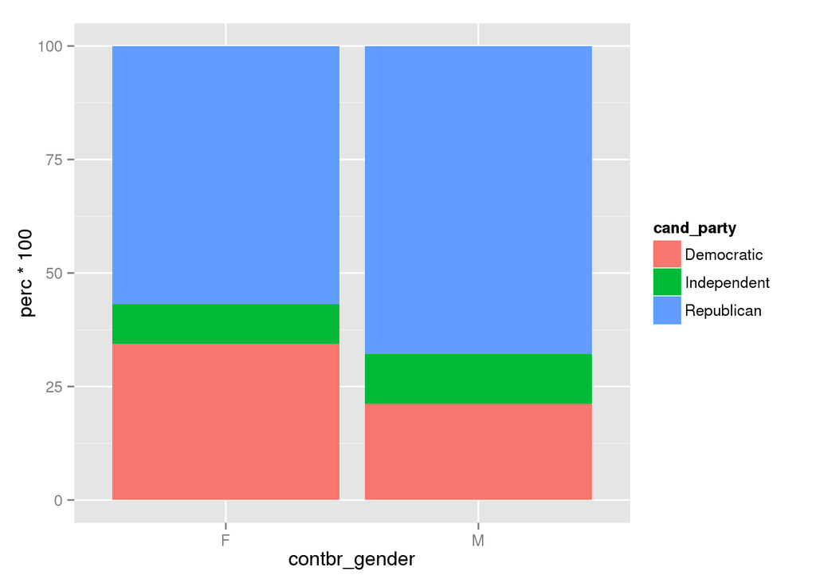

Now, the current most popular Democratic party candidate is a woman. It is possible that the female contributors are more likely to contribute to a female candidate?

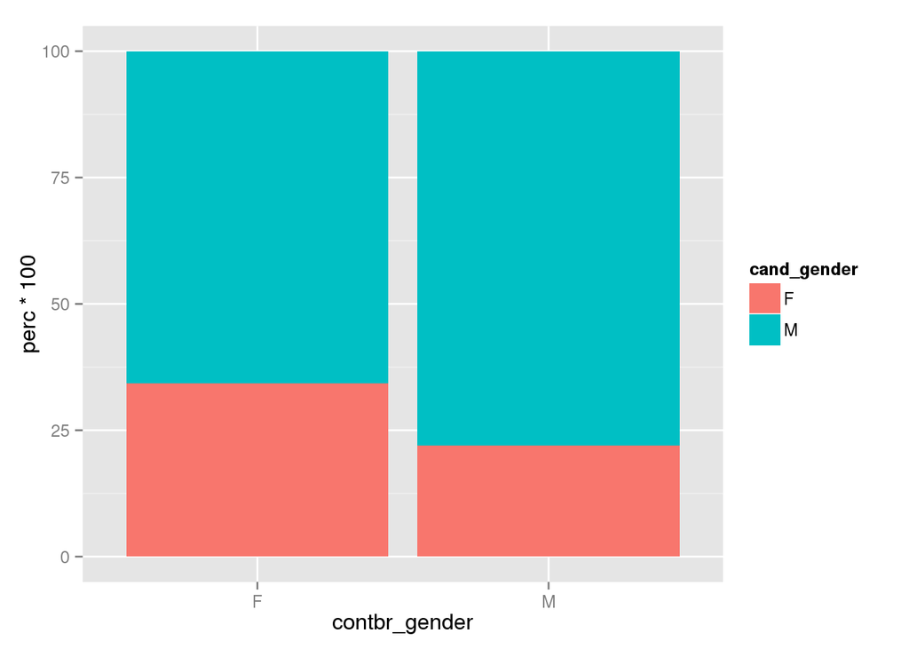

It certainly seems possible that female contributors are more likely to vote for female candidates but it is impossible to test. We cannot be sure if female contributors are contributing for the democratic candidate because she is female or they are contributing for the female candidate because she is democratic.

I would like to mention that I am looking at the effect of female candidates simply because they are less common than male candidates. It would be equally valid to suggest that men are more likely to contribute to male candidates (and equally inconclusive).

Let’s look at which how many contributions each candidate recieved from each gender.

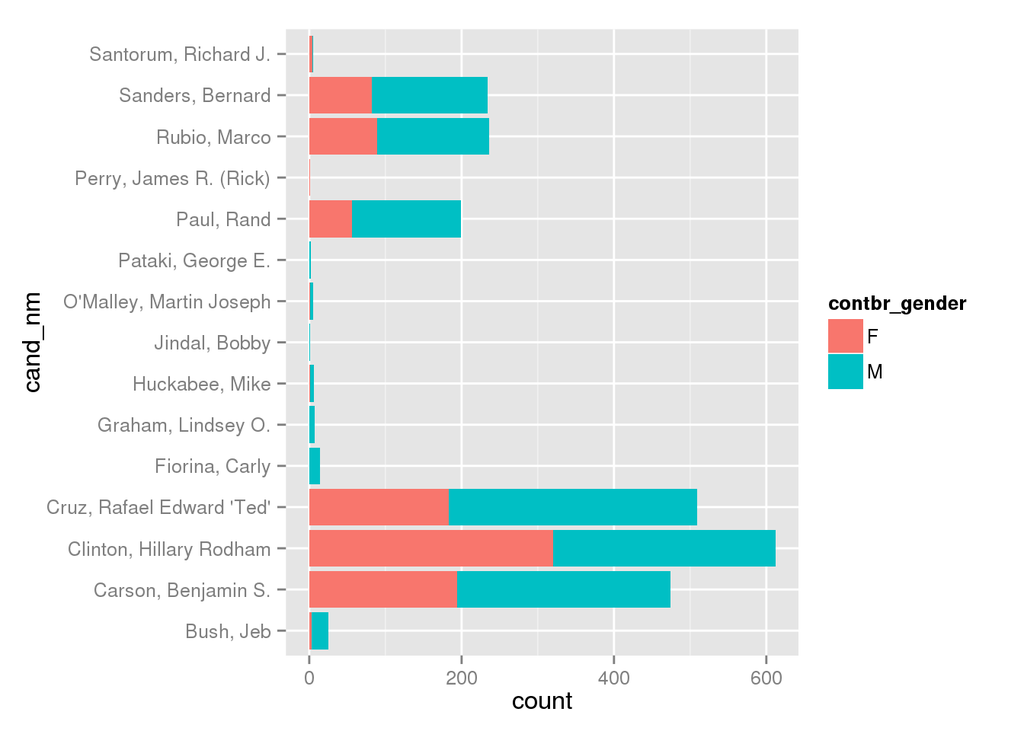

That will be easier to compare if we use percentages.

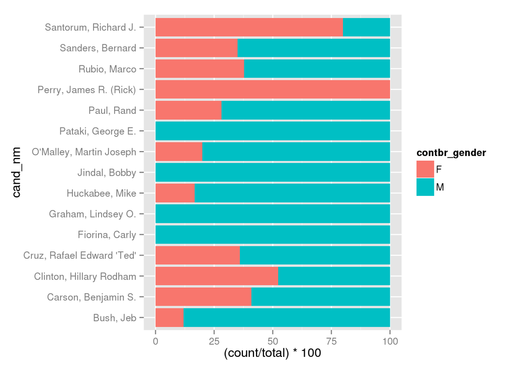

While it certainly looks like some candidates are radically preferred by a specific gender, it is important to remember that some candidates have a very low number of contributions so in fact the first plot is actually more usefull.

### Looking a bit more at the amount of the contributions

What is the mean contribution amount by occupation?

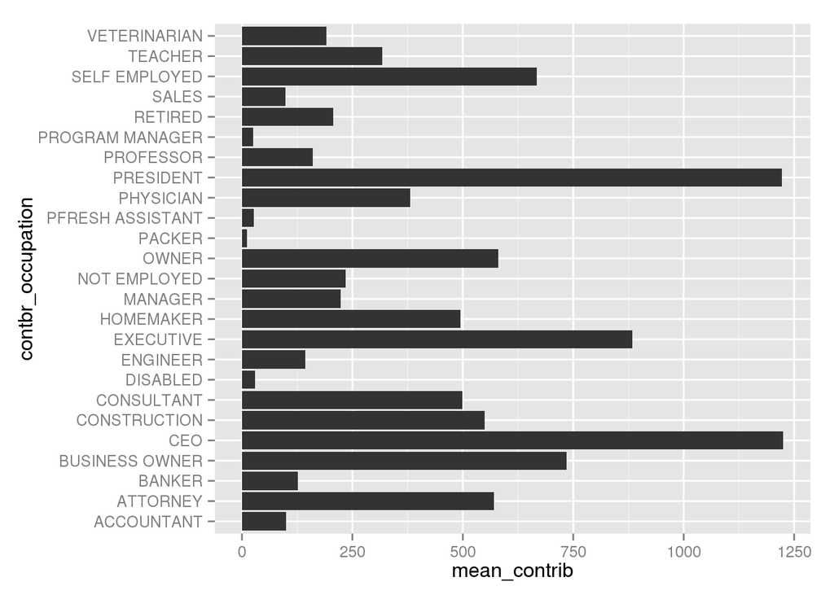

This is surprisingly close to what I’d expect with the occupations I’d imagine being better paid making larger contributions.

Let’s look at the mean amount by city.

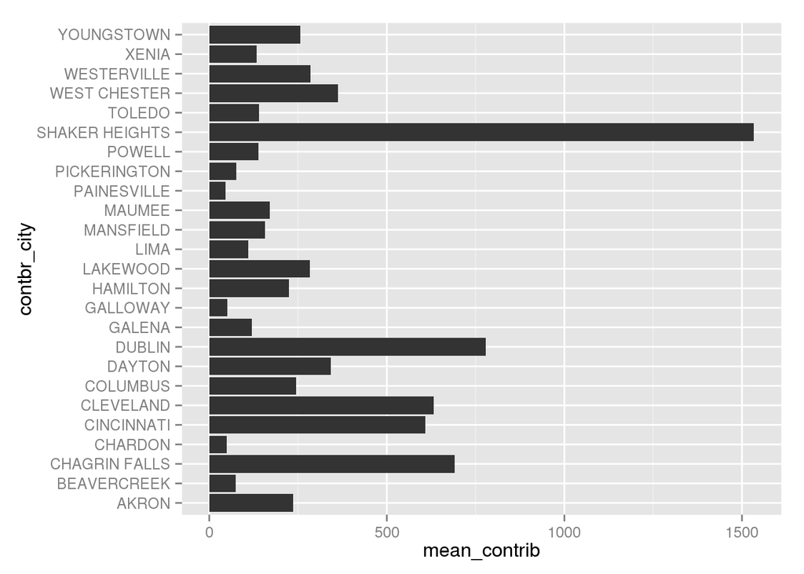

Shaker Heights looks like a nice place to live. It would be interesting to look at how affluent each city is (perhaps looking at mean property prices) but that is beyond the scope of this project.

I suspect that looking at the mean amount donated by gender won’t reveal much, but let’s look at it anyway.

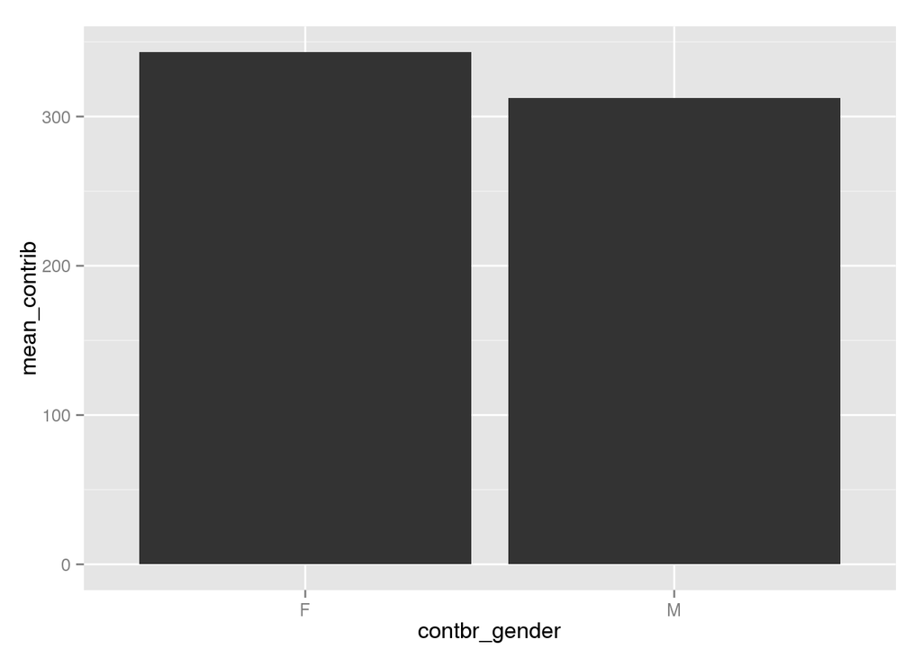

There doesn’t seem to be any meaningfull difference between the mean amounts contributed by each gender.

# Bivariate Analysis

### Talk about some of the relationships you observed in this part of the investigation. How did the feature(s) of interest vary with other features in the dataset?

There were some strong relationships between the city, the occupation and employer and our feature of interest - the candidate party. The relationships between city and occupation and candidate party were quite varied depending on which city or which occupation. The distribution of the amounts of the contribution by party was surprising. With the democratic party getting more contributions in the lowest range but the republican getting more contributions in the middle range.

The median amount of contributions was $100 for each party however there were big differences in the mean contribution amounts. The mean contribution amount for the democratic party was $520 while for the Republican party it was $264. The independant candidate had the lowest mean at $166 although, as there is only one independent candidate, perhaps it would make more sense to compare this to the mean amount of contributions for individual candidates.

The mean amount by candidate varied greatly and showed little correlation with the number of contributions or the total amount recieved by each candidate. The highest mean for any candidate was $1920 for Joseph O’Malley. The lowest was $129 for Lindsey O. Graham. Both of these have comparatively low total ammounts recieved so it is possible these extreme mean amounts are influenced by the low number of contributions received by each of them.

### What was the strongest relationship you found?

The relationship between employer and candidate party was very strong but ultimatly not that interesting as it is likely that contributors tend not to report their employer if they contribute to a party that their employer does not endorse.

# Multivariate Plots Section

### Amount of contributions by candidate and party

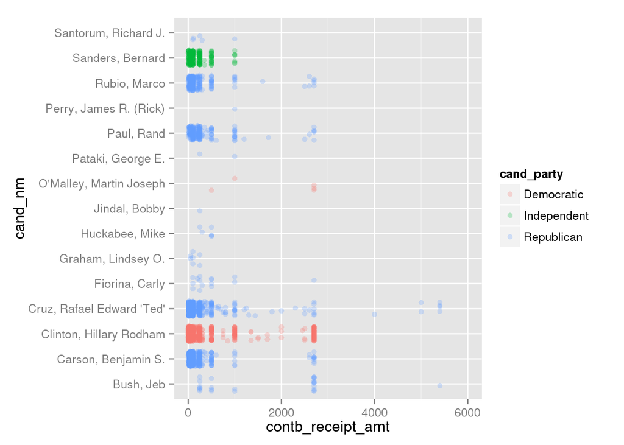

We can add candidate party information to this plot to see if there are any interesting patterns. However, as with previously, this plot is difficult to read with a catagorical x-axis that has a large number of factors.

We can also look at the mean donation amounts by candidate.

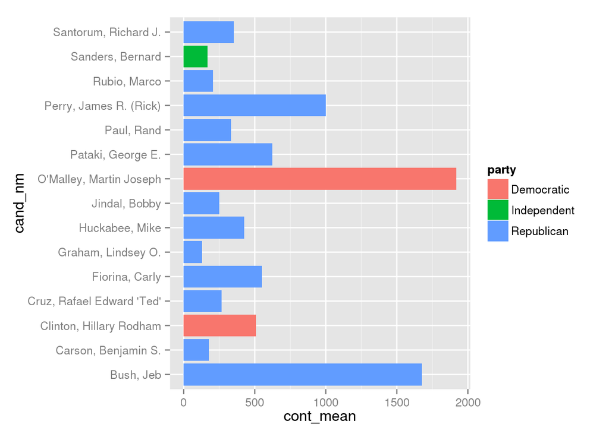

Looking back to the differences in mean amount of contribution for each party, it is easy to see how the variation in number of candidates has an effect on the mean. A number of Republican candidates have very high mean amounts of contribution however, as there are more republican candidates this has an effect on the mean by party.

### Amount of contributions to each candidate by gender.

We can look at the gender of the contributors and whether they are contributing more or less to each candidate.

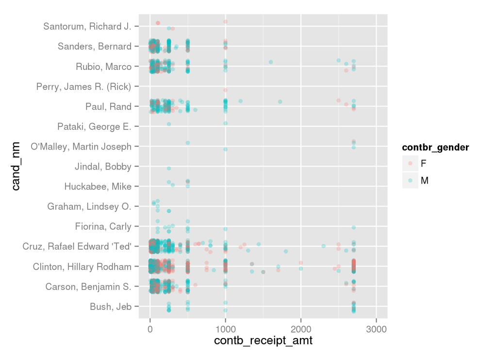

This plot has the same problems as the other point plots here. It is difficult to see any patterns, even with using a low alpha value and position jitter. If we look to the right of the graph, however, we can see that Hilary Clinton is getting a lot more high value donations from women than the other candidates.

### Amount of contributions over time.

We can look at the total amount of contributions by party over time.

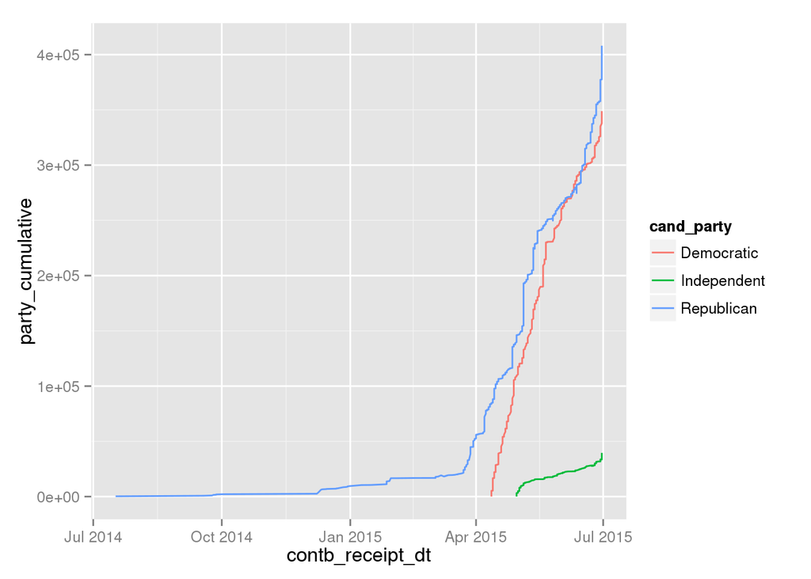

From this we can see the total amount contributed to each party is accumulating in a very similar fashion. The contributions to the Republican party started a lot earlier however the total amount for both parties started to rise steeply in April 2015.

We can also look at the amount contributed to each candidate by time.

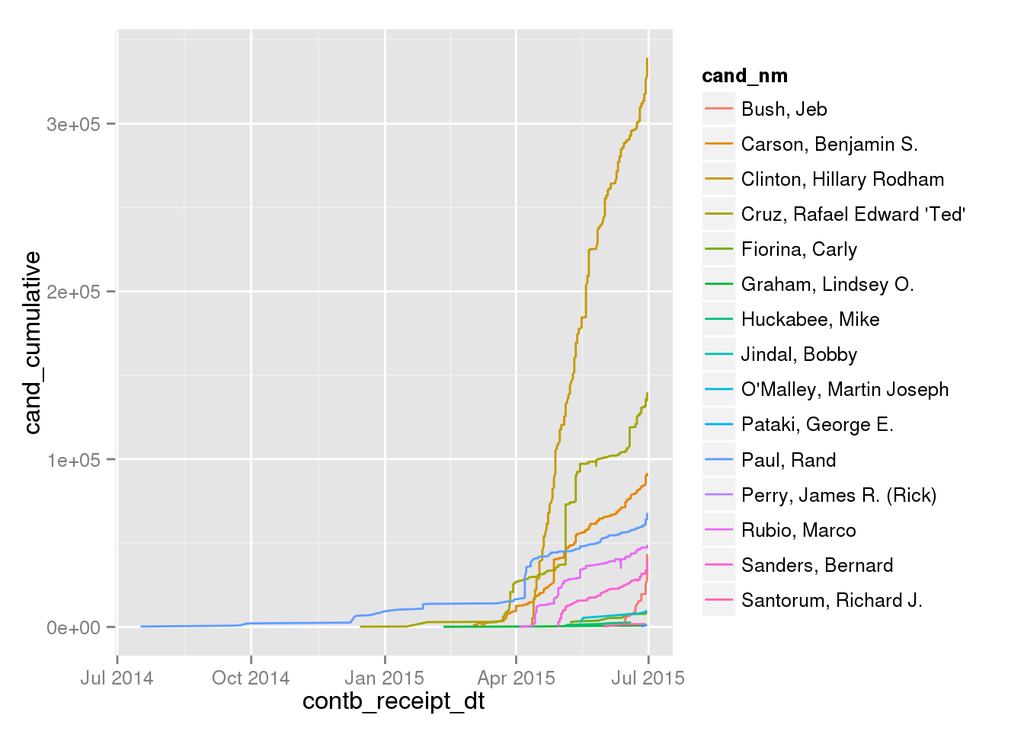

We can limit the x-axis to March onwards for more detail.

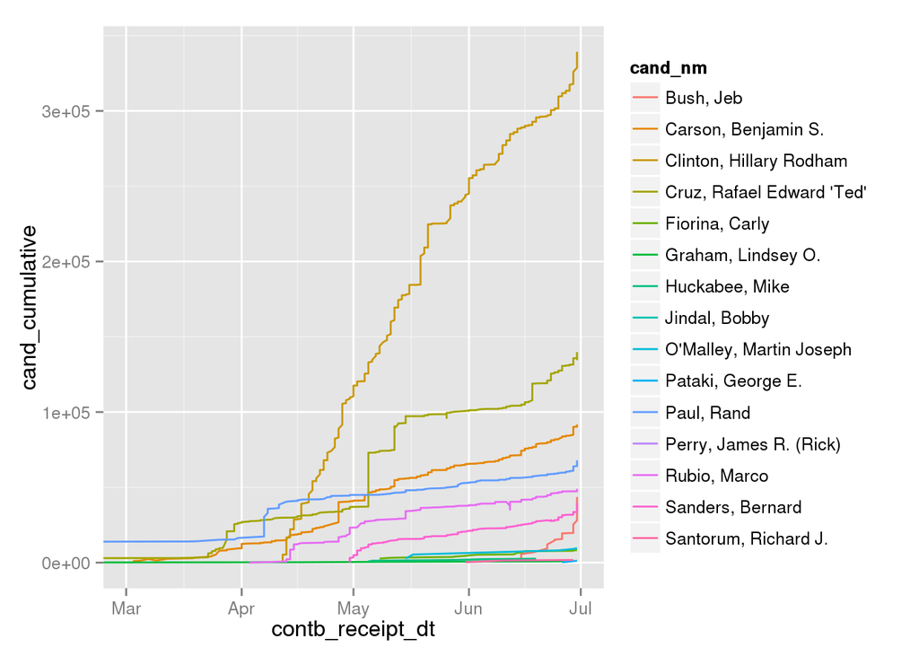

This gives us a quite different picture. Comparing this plot to the previous plot it is clear that while most contributions to the Democratic party are going to Hilary Clinton, the contributions to the Republican party are being split amongst a number of candidates.

As candidates anounced their candidancy at different times, we can adjust the plot for their different start dates.

### total amt / cand / runningdays

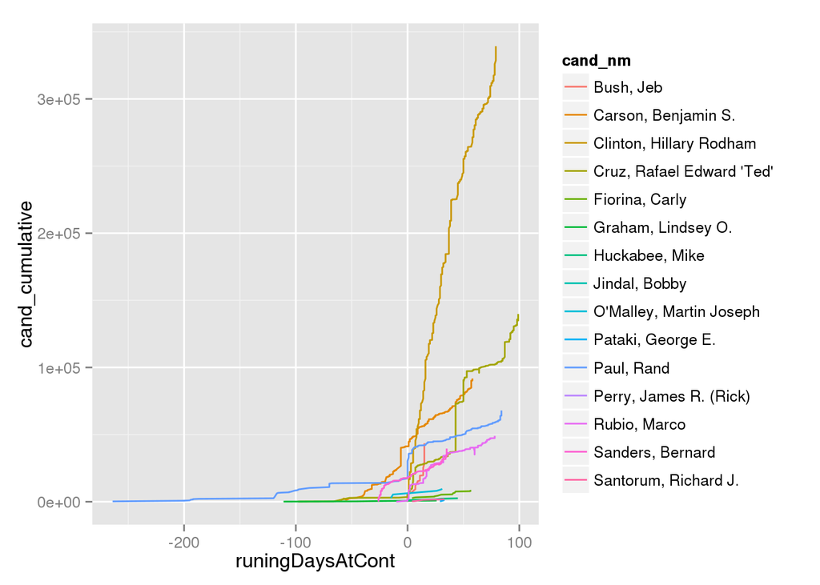

In fact there is not a lot of difference between this and the previous plot. We can see most candidants have contributions from before their candidancy was announced and for most of them, the rate of contribution did not change much after the announcement.

### How cities contribute

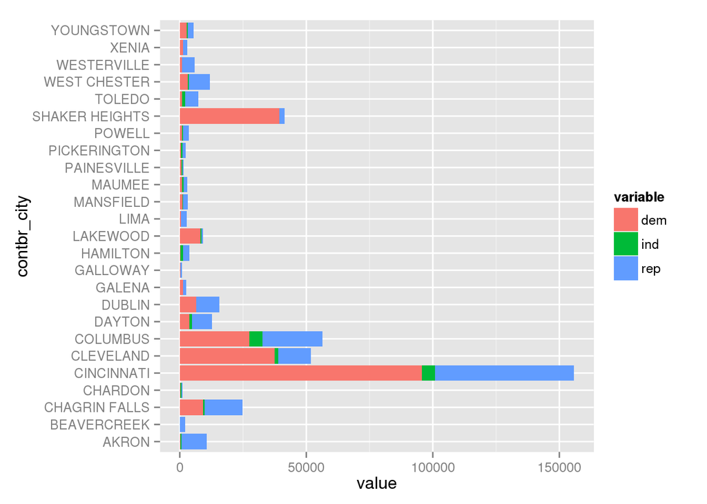

We did look at the percentage of contributions to each party previously and it was apparent some cities made more contributions to one party than another. Looking at the amount given by each city it becomes apparant that the cities giving the largest amounts are all giving slightly more to the democratic party. I would assume that the cities with the largest total contribution amounts are the largest cities however that would require further research to confirm.

### Differences in amount given by different occupations to each party.

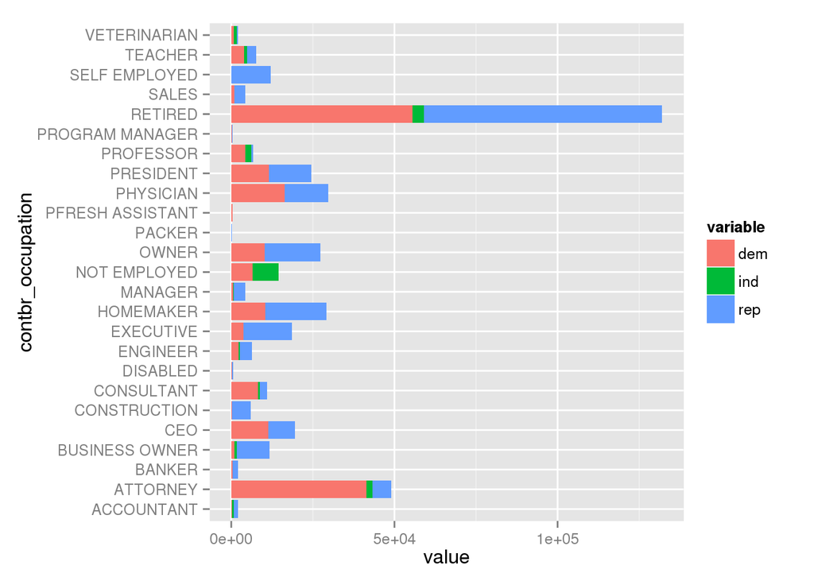

This really combines the information in our previous plots looking at occupation and party and occupation and amount contributed but does not offer any new insights.

### Distribution of amount by candidate and party

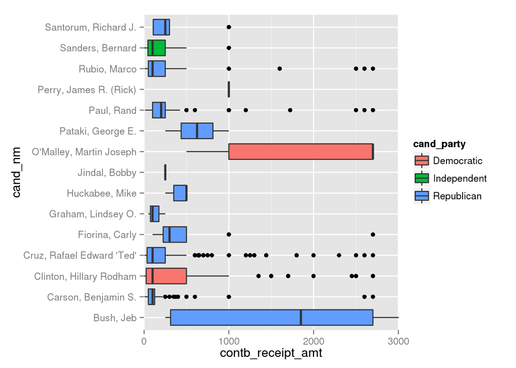

This plot shows a lot of information about the distributions of contributions to each candidate. I feel it is still a little misleading as it has no information about the number of contributions to each candidate which would explain some of the more unusual distributions (for instance Joseph O’Malley’s or Bobby Jindal’s distributions).

# Multivariate Analysis

### Were there any interesting or surprising interactions between features?

The total amounts contributed for each party were very similar when plotted over time. When the total amounts over time was plotted by candidate a very different picture emerged with Hilary Clinton having a much higher total than any other of the candidates.

# Final Plots and Summary

### Plot One

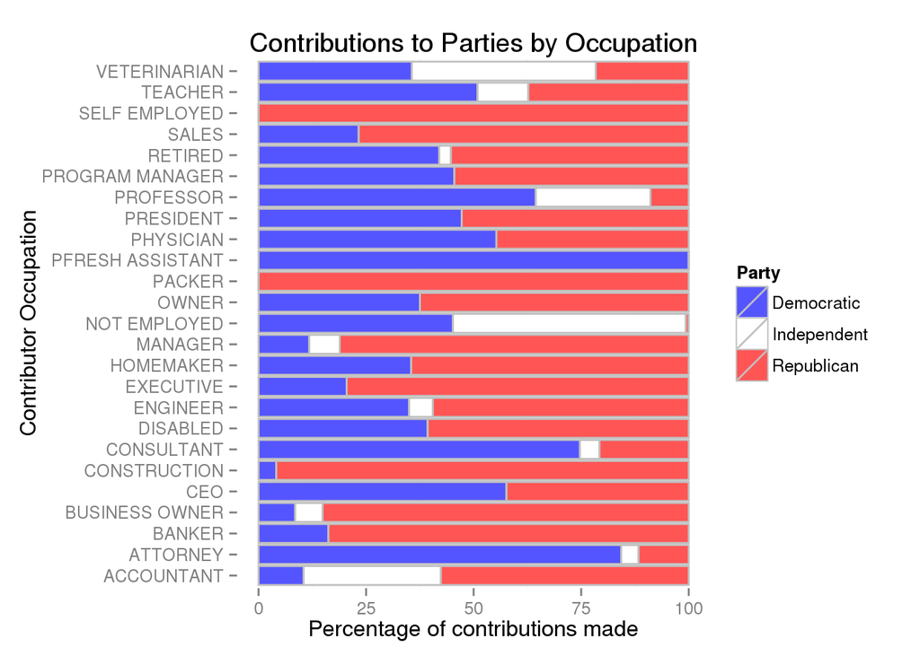

### Plot Two

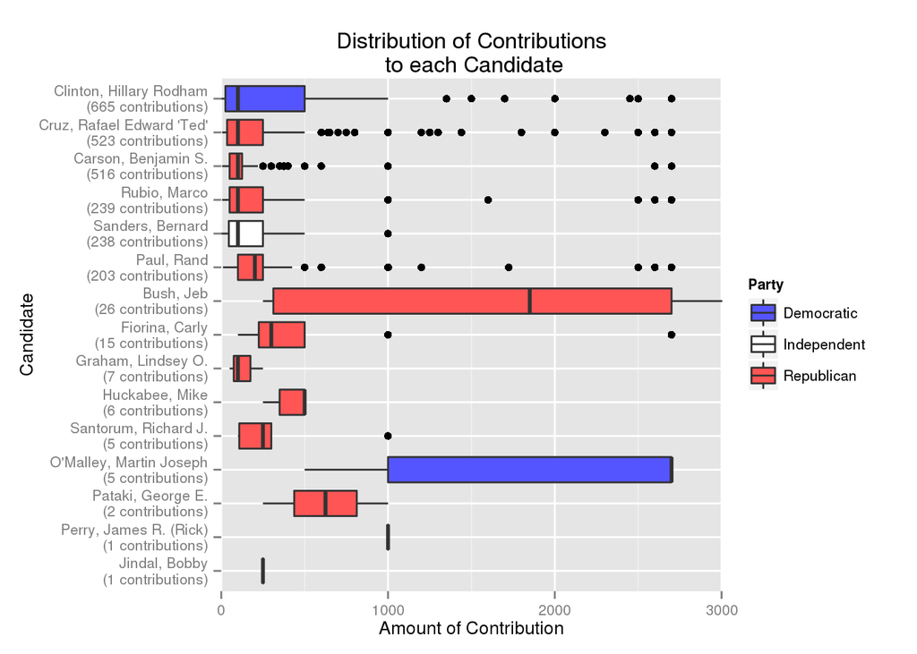

### Description Two

The distribution of contribution amounts varied quite a bit between candidates. In this chart I have ordered the candidates according to the number of contributions they have recieved. We can see that the more unusual contribution distributions occur with the candidates who have lower numbers of contributions. We can see that at the moment Hilary Clinton has the greatest variance amongst her contribution amounts for any candidate with more than a hundred contributions. Jeb Bush has a huge variance in his contribution amounts but has only recieved 26 contributions. This plot also allows us to see the banding of contributions around the $1000 mark.

### Plot Three

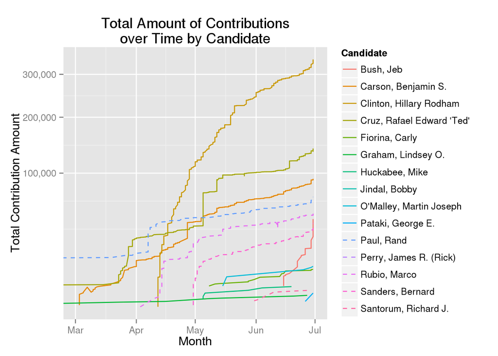

### Description Three

In this plot we can see the rate at which the total amount of contributions for each candidate is increasing. We can see that Hilary Clinton has the highest amount so far and, up until July at least, continues to recieve the highest amount in contributions. However Jeb Bush, whose only started running in the middle of June, seems to be recieving donations at a similar rate and could have caught up now that more time has past. A square root scale was used for the amount as it allows us to see the differences between the other candidates much more easily. Most candidates have a sharp rise at or near the begining of their campaign, presumably at the time they anounce their candidancy. Another interesting feature of this plot is the appearance of ‘steps’ in the lines. While Hilary Clinton’s plot is fairly linear, Ted Cruz’s plot is relatively flat with periodic jumps in the total amount. I would be interested to see if there are any specific events which tie in with these jumps. ——

# Reflection

This dataset has information on donations for the first few months of the 2016 Campaign. I started by looking at the candidates and the number of contributions they had received. It was obvious that some candidates did not have enough contributions to create any useful analysis, however about half the candidates had recieved substantial contributions. The information in the dataset was not enough on it’s own for very interesting analysis so I manually added features for the candidates, age, gender and party. I also added the date that they started campaigning as I felt that could be an important feature when explaining why some candidates had so many more contributions than others. In fact, it was only the candidates party which was of much use in the analysis. I was interested in the distribution of the amounts of the contributions both by party and by candidate. I noticed that the median contribution amount was the same for each party, however the mode and mean were radically different. Comparing histograms to look at the distribution of contributions at first appeared to show the same distribution. When I decreased the binsize however it became apparent that the Democratic parties contributions peaked in the smallest bin while the Republican party received more contributions in the next bin size. This difference became much more apparant when I split the donations into 20% quantile groups (instead of using linear bin groups) and charted how many contributions were made to each party in each group. I felt that the employer and occupation features were particularly interesting and there were a number of trends to be found within them. There were a number of occupation titles that were ambigious as well as a fair amount of overlap between some occupations. The biggest problem with these features was the low number of samples for each occupation or employer. Many of the problems with this data set would be overcome with updated data. The data is continually changing and since this dataset was collected a number of additional candidates have joined the presidential race. In addition, the low sample size problems with the occupations and employers would be alliviated with more up to date data. It will be interesting to revisit this project in a few months to see what has changed and what has stayed the same.